# SDMs: daily exercises

Clarke van Steenderen

2025-05-06

## Species Distribution Modelling: R proficiency exercises

Below are daily R exercises for you to complete. We will go over these together after you have tried them yourself. Part of our daily class discussion will involve issues you encountered with these exercises. Use the package help files to find out which parameters are needed. If you use AI such as ChatGPT to help you code, make sure that you understand what it’s doing, and that you have a very good grasp of the fundamentals.

### Set up, and ggplot specs

This is just to make sure that you have all the necessary libraries installed, and that your ggplots look nice.

```r
# create folders in your working directory in which to store data and figures as you proceed. The !dir.exists ensures that the folder isn't overwritten if it exists already

if (!dir.exists("data")) dir.create("data")
if (!dir.exists("figures")) dir.create("figures")

pacman::p_load(
  NicheMapR, magrittr, dplyr, tidyr, janitor, raster, sp, ggplot2, rgbif, dismo,
  ENMeval, sf, readr, terra, geodata, rnaturalearth, corrplot, gtools, igraph, usdm,
  factoextra, gridExtra, ecospat, forcats
)

# Change ggplot theme
theme_set(
  theme_classic() +
    theme(
      panel.border = element_rect(colour = "black", fill = NA),
      axis.text = element_text(colour = "black"),
      axis.title.x = element_text(margin = unit(c(2, 0, 0, 0), "mm")),
      axis.title.y = element_text(margin = unit(c(0, 4, 0, 0), "mm")),
      legend.position = "none"
    )
)

# Set the theme for the maps
theme_opts = list(
  theme(
    panel.grid.minor = element_blank(),
    panel.grid.major = element_blank(),
    panel.background = element_rect(fill = 'white', colour = NA),
    plot.background = element_rect(),
    axis.line = element_blank(),
    axis.text.x = element_text(colour = "black"),
    axis.text.y = element_text(colour = "black"),
    axis.ticks = element_line(colour = "black"),
    axis.title.x = element_text(colour = "black"),
    axis.title.y = element_text(colour = "black"),
    plot.title = element_text(colour = "black"),
    panel.border = element_rect(fill = NA),
    legend.key = element_blank()
  )
)
```

## Week 1

### Exercise 1

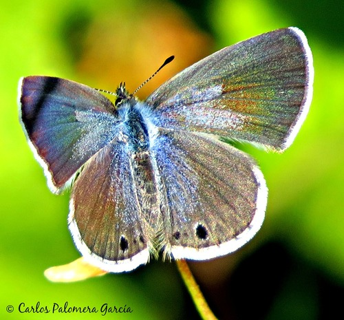

Use the `geodata::sp_occurrence()` function to download all the available records for the endangered Brenton Blue butterfly, *Orachrysops niobe*, from the GBIF database.

- Do a quick count of how many occurrences there were for each country in the `country` column. Hint: use `dplyr::count()`
- Do another count, but this time for the occurrences in each province in the `adm1` column
- In the `adm1` column for province, replace all NAs with “unknown”
- Create a bar plot using `ggplot2`, where you show the total record counts per province. Set the y-axis range from 0 to 45, with intervals of 5. Colour the bars any colour you like, and give them a black border (use `fill = "your_colour", colour = "black")` to do this
- See if you can order the bars from largest to smallest, using the `fct_infreq()` function in the `forcats` library
- Create a new data frame, where you keep only the `species`, `lat`, and `lon` columns
- Remove all duplicate GPS records from this data frame
- Using `nrow()`, print out the number of rows in the original download and in the cleaned version (after duplicates were removed)
- Save the final data frame as both an RDS and CSV file

Some starting code is provided to get you going:

```r
# Download all available records from GBIF
or.niobe = geodata::sp_occurrence(
  genus = "Orachrysops",
  species = "niobe",
  download = TRUE,
  geo = TRUE,
  removeZeros = TRUE
)

# count records per country
# create a bar plot
# Select the specified columns
# Remove duplicate GPS records

# save as an RDS file
saveRDS(object = or.niobe_final, file = "data/or.niobe.rds")

# save as a CSV
```

### Exercise 2

Read in your saved RDS data frame saved in Exercise 1, and:

- Plot all the records for *Orachrysops niobe* onto a map of South Africa (use `rnaturalearth::ne_countries(scale = "medium", returnclass = "sf") %>% dplyr::filter(name %in% c("South Africa"))`)
- Colour the GPS points dark red
- Crop the map to exclude Marion Island (use `coord_sf(crs = 4326, xlim = c(16, 33), ylim = c(-35, -22), expand = FALSE)` to set the x and y limits)
- Give the map an appropriate title (`ggtitle("title_here")`)
- Try to add in a North arrow (`ggspatial::annotation_north_arrow()`) and scale bar to the map (`ggspatial::annotation_scale(`)
- Save the map as an RDS file, and a PNG image (5 x 5, dpi = 350)

Your ggplot function should follow this template:

```r
# get South Africa raster map
southafrica_ext = rnaturalearth::ne_countries(scale = "medium", returnclass = "sf") %>%
                  dplyr::filter(name %in% c("South Africa"))

# Plot GPS points on SA map
YOUR_MAP = ggplot() +
  # Add raster layer of SA map
  geom_sf(data = southafrica_ext, alpha = 0.5, fill = "grey80") +
  # Add your GPS points
  geom_point(
    data = YOUR_DATA,
    size = YOUR_SIZE,
    colour = "YOUR_COLOUR",
    aes(x = lon, y = lat)
  )  +
  # Set SA CRS, and crop
  coord_sf(
    crs = 4326,
    xlim = c(16, 33),
    ylim = c(-35, -22),
    expand = FALSE
  ) +
  xlab("Longitude") +
  ylab("Latitude") +
  ggtitle("YOUR_TITLE") +
  # ADD SCALE BAR
  # ADD NORTH ARROW
  )
```

Your map should look something like the one below. You will notice that Lesotho and Eswatini/Swaziland are coloured white, and therefore excluded. Try to include these in another version of the map. Hint: Eswatini needs to be referred to as `"eSwatini"` when you select country names in the `rnaturalearth::ne_countries()` function.

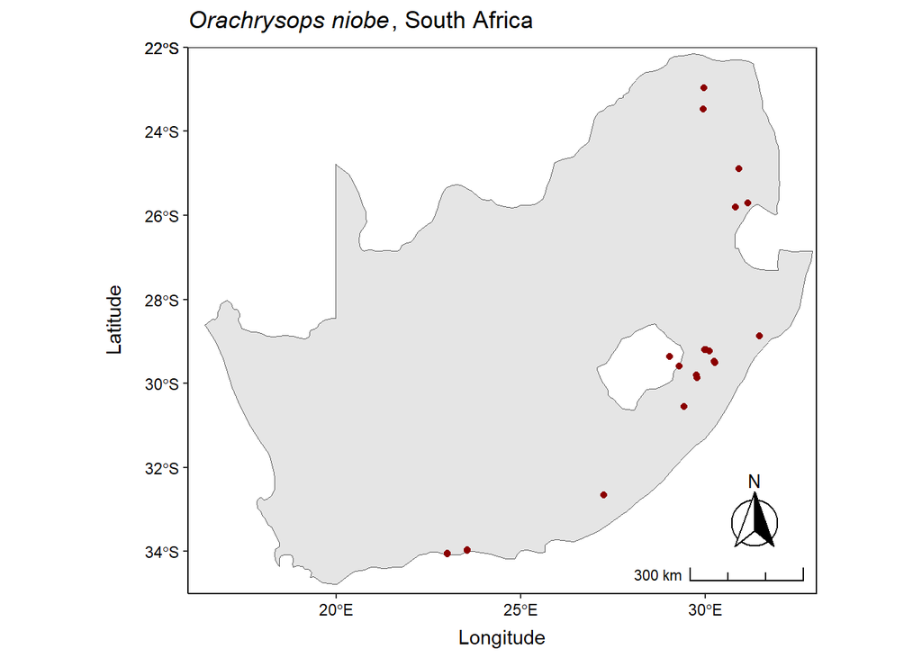

### Exercise 3

The command `provincial_borders = ne_states(country = "South Africa", returnclass = "sf")` provides South African provincial boundaries. See if you can add these to your ggplot map from Exercise 2.

- Now colour the provinces, so that the Western Cape Province is `lightgreen`. To colour individual provinces, you will need to use `aes(fill = name)`, such that: `geom_sf(data = provincial_borders, color = "black", aes(fill = name))`, followed by `scale_fill_manual()`, where you need to supply a colour to each province. E.g. `scale_fill_manual(values = c(Northern Cape = "grey80, ....))`
- Save the map as a 5 x 5 PNG image with a dpi of 350, AND as an RDS file.

Some tips are given below:

```r
southafrica_ext = rnaturalearth::ne_countries(scale = "medium",
                  returnclass = "sf") %>%
                  dplyr::filter(name %in% c("South Africa"))

# provincial borders
provincial_borders = rnaturalearth::ne_states(country = "South Africa", returnclass = "sf")

YOUR_MAP = ggplot() +
  # Add raster layer of SA map
  geom_sf(data = southafrica_ext, alpha = 0.5, fill = "grey80") +
  # Add provincial borders
  geom_sf(data = provincial_borders, color = "black", aes(fill = name)) +
  # Colour provinces individually
  scale_fill_manual(
    values = c(
      "Northern Cape" = "grey80",
      "KwaZulu-Natal" = "grey80",
      "Free State" = "grey80",
      "Eastern Cape" = "grey80",
      "Limpopo" = "grey80",
      "North West" = "grey80",
      "Mpumalanga" = "grey80",
      "Western Cape" = "grey80",
      "Gauteng" = "grey80"
    ),
    name = "Province"
  ) +
  # Add your GPS points
  # Add the rest of the plotting parameters, as before

  # Save as an RDS and PNG
```

The map should look something like this:

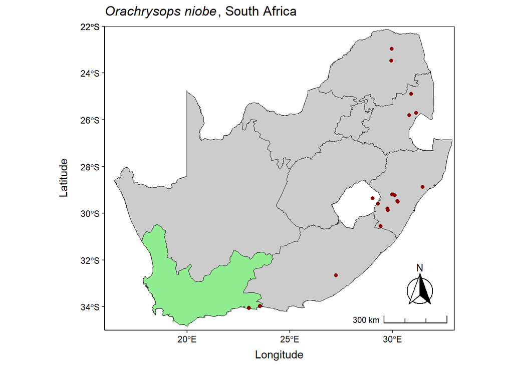

### Exercise 4

Download all the occurrence records of a second endangered butterfly, *Lepidochrysops outeniqua* (Outeniqua Giant Cupid).

- As before, keep only the `species`, `lat`, and `lon` columns, and remove all duplicate GPS records
- Read in the South African map you created in Exercise 3 (RDS file), and add the GPS records of *L. outeniqua* to that
- Plot the GPS records for *L. outeniqua* as white circles with a black border, with a size of 2.5. Hint: to get the circles to have a different fill and outline colour, set the shape to 21 using `pch = 21`, and then assign `fill` and `colour` separately, where `colour` determines the outline
- Save the map as both a PNG and RDS file

The map should resemble this:

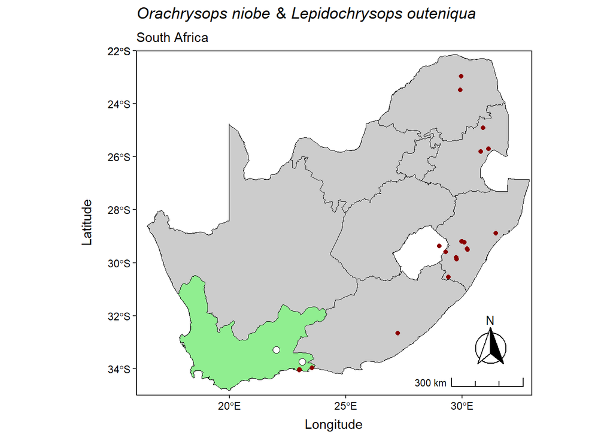

### Exercise 5

You now have two data frames, one for *Orachrysops niobe*, and one for *Lepidochrysops outeniqua*.

- Combine these two data frames. You can use either the base R function `rbind()`, or dplyr’s `bind_rows()`
- Filter out any GPS coordinates north of 28 degrees South (i.e. latitude > -28)
- Re-plot this data on the map of South Africa, and this time use the `species` column as a factor for colouring. Choose any two colours you like for the species, and include a legend on the plot.

Use `rbind` as shown in the example below:

```r
dataframe1
dataframe2

combined.df = rbind(dataframe1, dataframe2)
# or
combined.df = dplyr::bind_rows(dataframe1, dataframe2)
```

Your map should look like this:

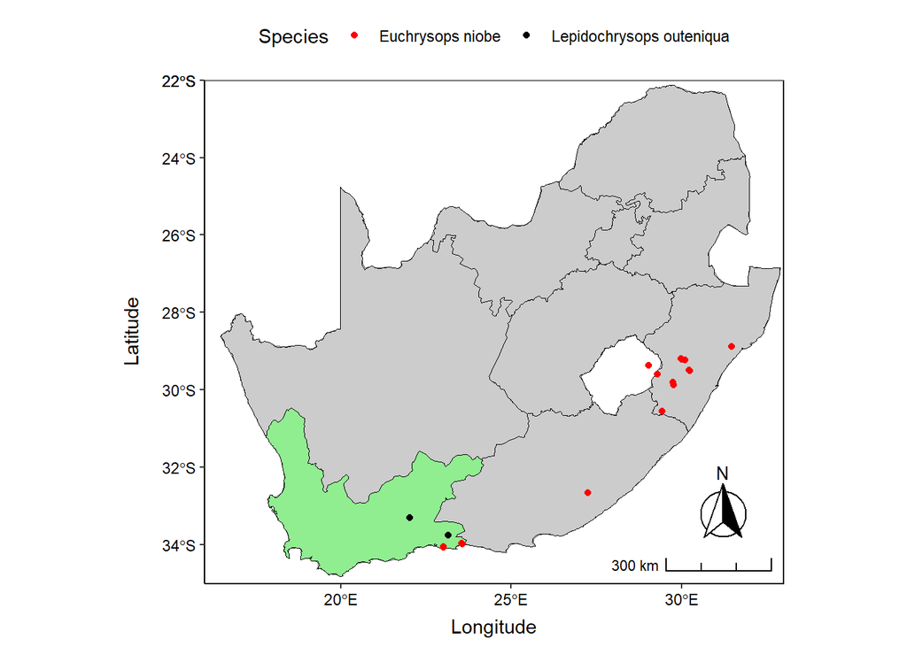

### Create your own function

So far, you have encountered numerous R functions to process your data, run statistical tests, create graphics, etc. You can create your own functions quite easily, if you have repetitive code that you need to re-run with different inputs.

In simple terms, a function is like a recipe for a meal: it has a name, requires ingredients, provides instructions for preparation, and then outputs a final dish. In this analogy, `CHICKEN.PIE` is the **name of the function**, and the ingredients between the function’s round brackets, `function()`, are **parameters** that the recipe needs. Everything between the outer curly braces, `{}` contains the instructions for completing the recipe/function. At the end of the process, the recipe outputs the final product using the `return()` function.

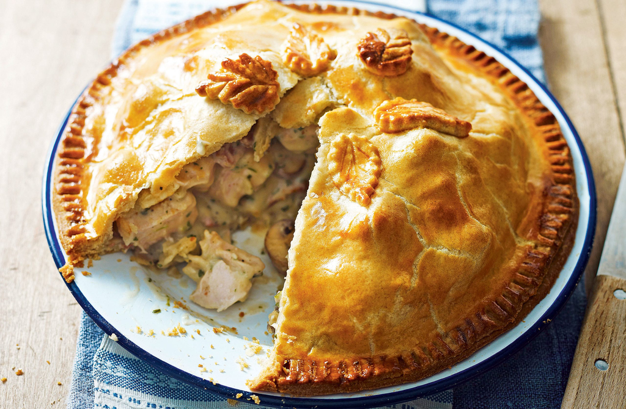

```r
CHICKEN.PIE = function(PASTRY, CHICKEN, VEG, BAKE.TEMP, BAKE.TIME, GARNISH){

  MY.PIE =
    mix(PASTRY + CHICKEN + VEG) %>%
    bake(BAKE.TEMP * BAKE.TIME) %>%
    finish(GARNISH)

  return(MY.PIE)
}

# then call up your recipe like this
CHICKEN.PIE(PASTRY = "flaky", CHICKEN = "drumsticks", VEG = "mushrooms", BAKE.TEMP = 180, BAKE.TIME = 60, GARNISH = "parsley")
```

Below is an example of how you would structure a function in R that produces a simple box plot given a series of values and a grouping variable (here, we’ll create 100 random positive numbers, and randomly assign `A`, `B`, or `C` to each value as a grouping variable).

```r
# Create your function
myboxplot = function(DF, value_col, group_col, fill.col = "lightpink") {

 plot = ggplot(DF, aes(x = .data[[group_col]], y = .data[[value_col]], fill = .data[[group_col]])) +
  geom_boxplot(color = "black", fill = fill.col) +
  theme_classic() +
  labs(x = group_col, y = value_col, title = "My Boxplot Function")

 return(plot)
}

# Create some example data -> randomly create 100 values, and randomly assign
# A, B, or C to each
df = data.frame(
  value = abs(rnorm(100)),
  group = sample(c("A", "B", "C"), 100, replace = TRUE)
)

head(df)
```

```
##       value group
## 1 0.1830367     C
## 2 0.1200557     B
## 3 1.1631954     B
## 4 0.7462430     C
## 5 1.9034806     C
## 6 0.5069643     A
```

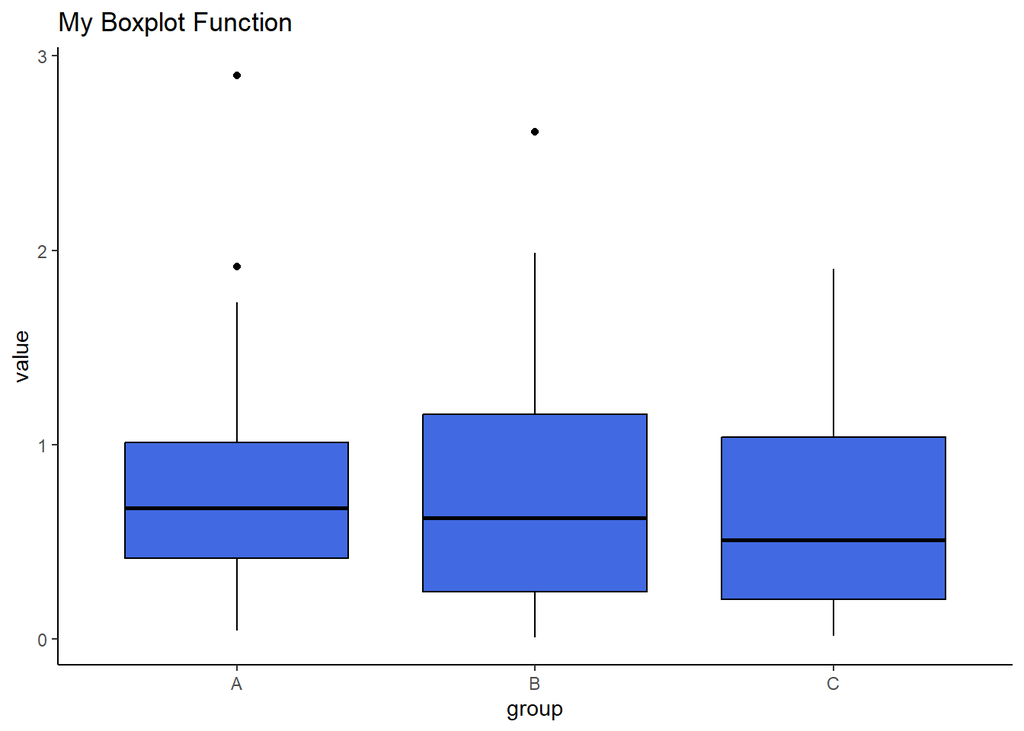

```r
# Call your function
myboxplot(df, value_col = "value", group_col = "group", fill.col = "royalblue")
```

Over to you:

- Adapt the `myboxplot` function above to allow the user to (1) specify the alpha value for colouring the plot, and (2) edit the axis labels and plot title
- Now, create your own new function that plots a map of South Africa. This function should take in three parameters: (1) a data frame that contains lat and lon GPS points, (2) the name of the column containing the latitude values, and (3) the name of the column containing the longitude values. Use the code below that we used previously as a framework. If you want to, you can also add the colour of the points as an additional parameter, and the ability to change the point size, shape, position of the North arrow and scale bar, etc.

```r
mySAmap = function(PARAMETER1, PARAMETER2, PARAMETER3){

southafrica_ext = rnaturalearth::ne_countries(scale = "medium", returnclass = "sf") %>%
                  dplyr::filter(name %in% c("South Africa"))

map = ggplot() +
  # Add raster layer of SA map
  geom_sf(data = southafrica_ext, alpha = 0.5, fill = "grey80") +
  # Add GPS points
  geom_point(
    data = PARAMETER,
    size = 1.5,
    colour = "darkred",
    aes(x = .data[[PARAMETER]], y = .data[[PARAMETER]])
  )  +
  # Set CRS
  coord_sf(
    crs = 4326,
    xlim = c(16, 33),
    ylim = c(-35, -22),
    expand = FALSE
  ) +
  xlab("Longitude") +
  ylab("Latitude") +
  ggspatial::annotation_scale(
    location = "br",          # 'bl' = bottom left
    style = "ticks",
    width_hint = 0.2
  ) +
  # Add north arrow
  ggspatial::annotation_north_arrow(
    location = "br",
    which_north = "true",
    pad_x = unit(0.175, "in"),
    pad_y = unit(0.3, "in"),
    style = ggspatial::north_arrow_fancy_orienteering
  ) +
  theme_classic()

return(map)

} #mySAmap function

# now test the function on any of the data sets we downloaded from GBIF in earlier exercises
```

### Exercise 6

This activity will teach you a little more about lists in R. A list is a container which can hold one or more objects. Perhaps you have two data frames containing GBIF information, you can pack them both into a single list. Below is a simple example of how you can combine objects into a list. Here, we’ll create three data frames containing five random numbers between 1 and 100, and then store them in a list called `mylist`. We’ll call the first item in the list, DF1, `spA`, the second, DF2, `spB`, and the last `spC`. Once created, you can refer to your individual data frames using the `$` sign; for example `mylist$spA`. If you want to later combine all the objects in your list into a single data frame, you can run `dplyr::bind_rows(mylist, .id = "source")`, where `.id = "source"` ensures that an additional grouping column is included to tell you which object (here `spA, spB, spC`) each value came from.

```r
# create random data frames
DF1 = data.frame(values = sample(1:100, 5))
DF2 = data.frame(values = sample(1:100, 5))
DF3 = data.frame(values = sample(1:100, 5))

# shuttle them into a list
mylist = list(spA = DF1, spB = DF2, spC = DF3)

# refer to the individual objects like this:
mylist$spA
```

```
##   values
## 1     72
## 2     16
## 3     93
## 4     64
## 5     33
```

```r
mylist$spB
```

```
##   values
## 1      2
## 2     65
## 3     30
## 4     91
## 5     60
```

```r
mylist$spC
```

```
##   values
## 1     77
## 2      8
## 3     24
## 4      5
## 5     36
```

```r
# if you want to combine all objects in the list into one DF, you can run:
combo_df = dplyr::bind_rows(mylist, .id = "source")
```

What we can do now is loop through each item in our `mylist` list, and perform some kind of check or operation. For example, we can sum the values in each `sp` object in our list, and print the result to the screen. `for-loops` take the following format:

```r
for(item in container){
  # run some code
  # access an item by referencing its position in the list:
  container[[item]]
}
```

In our example (`k` can be anything you want; `i`, `item`, etc. It simply acts as a counter that starts at 1 and ends at the size of the list; here that would mean that it runs from 1 to 3, since we had 3 items in our list):

```r
for(k in 1:length(mylist)){
  print( sum(mylist[[k]]) )
}
```

```
## [1] 278
## [1] 248
## [1] 150
```

```r
# if you want to add some descriptive output text:
for(k in 1:length(mylist)){
  print(paste0("The sum of ", names(mylist[k]), " is: ", sum(mylist[[k]]) ) )
}
```

```
## [1] "The sum of spA is: 278"
## [1] "The sum of spB is: 248"
## [1] "The sum of spC is: 150"
```

There is an even shorter way of running a loop, using `sapply`:

```r
sapply(mylist, sum, USE.NAMES = TRUE)
```

```
## spA spB spC
## 278 248 150
```

#### For you to do:

[figure not shown]

- Download GBIF occurrence records for three new species: (1) the Berg adder (*Bitis atropos*), (2) the Albany adder (*Bitis albanica*), and (3) the many-horned adder (*Bitis cornuta*)
- Create a single list, called `bitis.list`, that contains all three of these data frames, and call the objects `b.atropos`, `b.albanica`, and `b.cornuta` respectively.
- Write a simple `for-loop` that iterates over each object in `bitis.list`, and writes to the screen the number of unique people’s names who identified the records in the `identifiedBy` column. Hint: you can then find the unique entries in a column by using `unique("identifiedBy")`. Here’s some code to help you:

```r
# download GPS points for the three adder species

# create the list
bitis.list = list(b.atropos = YOURDATA,
                  b.albanica = YOURDATA,
                  b.cornuta = YOURDATA)

# run the loop
for(k in 1:length(bitis.list)){

  unique.people = unique(bitis.list[[k]]["identifiedBy"])
  YOURCOUNT = # code here to find the number of entries in unique.people

  print(paste0(names(bitis.list[k]), " has ", YOURCOUNT, " unique human identifers"))

}
```

As a final exercise for this section:

- Combine the three objects in `bitis.list` into one data frame, and call this `combo_bitis`
- Modify the function you created in the previous exercise (`mySAmap()`) to accept an additional parameter for a grouping column. Call this function `mySAmap.groups`
- Plot a map of South Africa with the GPS coordinates of the three adder species, where you colour each species differently using default colours. If you want to add a different palette of default colours, try adding something like `scale_color_brewer(palette = "Set1")` to your ggplot. Google some other palette sets that you could use
- Run your function a second time, but this time around filter the GPS coordinates so that you remove the points in Namibia. You can use `dplyr::filter(combo_bitis, country == "South Africa")`. If you want to keep Lesotho and eSwatini as well, you can use: `dplyr::filter(combo_bitis, country %in% c("South Africa", "Lesotho", "Swaziland", "eSwatini"))`
- If you want to edit the legend title and names of groups, you can add this to your final plot:

```r
scale_color_brewer(
  palette = "Set1",
  name = "Species",
  labels = c(
    "b.albanica" = "B. albanica",
    "b.atropos"  = "B. atropos",
    "b.cornuta"  = "B. cornuta"
  )
)

# OR

scale_color_discrete(
  name = "Species",
  labels = c(
    "b.albanica" = "B. albanica",
    "b.atropos"  = "B. atropos",
    "b.cornuta"  = "B. cornuta"
  )
)
```

Here’s some help:

```r
# combine the objects in bitis.list
combo_bitis = # your code

# modified function
mySAmap.groups = function(GPS.POINTS, LON.COL, LAT.COL, NEWPARAMETER){

southafrica_ext = rnaturalearth::ne_countries(scale = "medium", returnclass = "sf") %>%
                  dplyr::filter(name %in% c("South Africa"))

map = ggplot() +
  # Add raster layer of world map
  geom_sf(data = southafrica_ext, alpha = 0.5, fill = "grey80") +
  # Add GPS points
  geom_point(
    data = GPS.POINTS,
    size = 1.5,
    aes(x = .data[[LON.COL]], y = .data[[LAT.COL]], colour = NEWPARAMETER)
  )  +
  # Set world map CRS
  coord_sf(
    crs = 4326,
    xlim = c(16, 33),
    ylim = c(-35, -22),
    expand = FALSE
  ) +
  xlab("Longitude") +
  ylab("Latitude") +
  ggspatial::annotation_scale(
    location = "br",          # 'bl' = bottom left
    style = "ticks",
    width_hint = 0.2
  ) +
  # Add north arrow
  ggspatial::annotation_north_arrow(
    location = "br",
    which_north = "true",
    pad_x = unit(0.175, "in"),
    pad_y = unit(0.3, "in"),
    style = ggspatial::north_arrow_fancy_orienteering
  ) +
  theme_classic()

return(map)

} #mySAmap.group function

bitis.map = mySAmap.groups(# test your function here)

# run the function again, keeping only SA points
```

Your map should resemble:

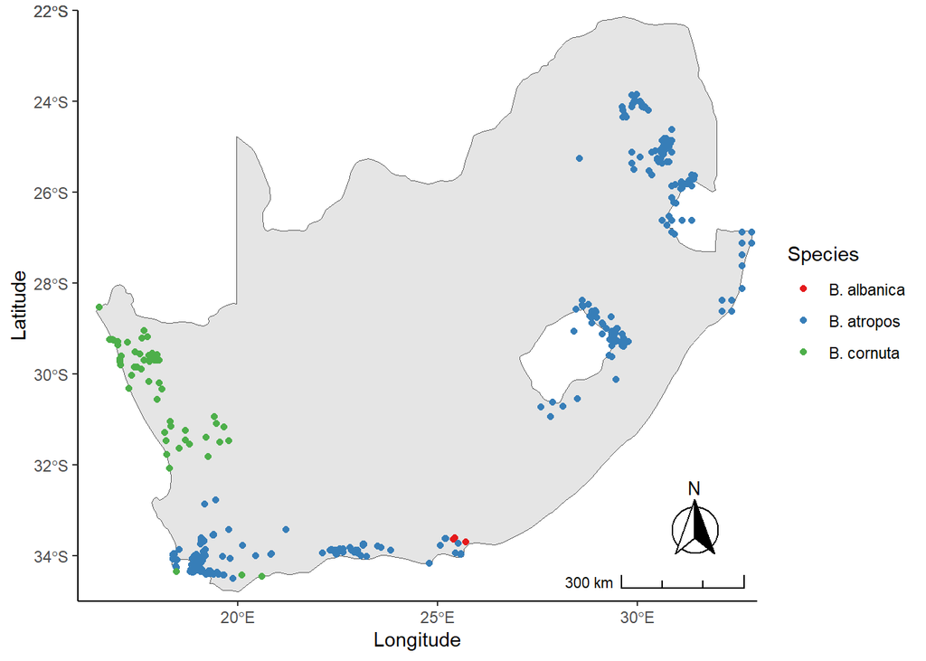

## Week 2

### Exercise 1

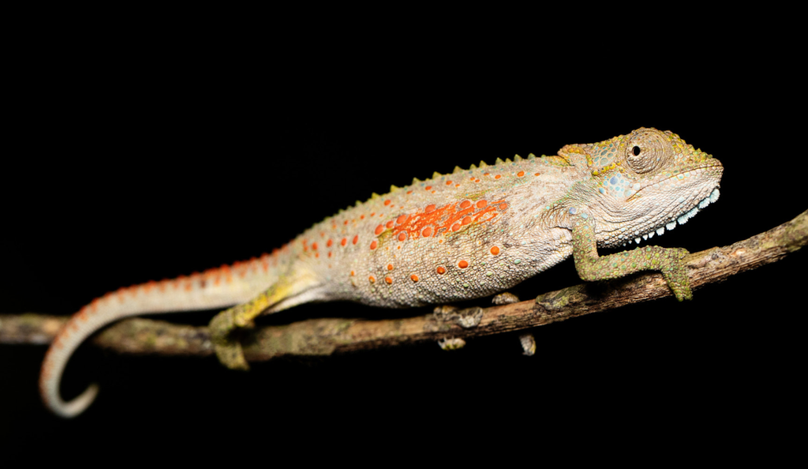

Again using `geodata::sp_occurrence()`, download all the available GBIF records for the Namaqua dwarf chameleon, *Bradypodion occidentale*.

- The `adm1` column contains the Province names - change this to a factor using `as.factor()`, and look at how many unique Province names are present (use `levels()`)
- Using the `mutate()` and `recode()` functions in the `dplyr` package (or another if you find one), change every instance of “Cape Prov.” to “Western Cape”, and “Northern Cape Prov.” to “Northern Cape” in the `adm1` column. Check the levels again to make sure that the change was implemented.
- Save the data frame as an RDS file.

### Exercise 2

Read the RDS file back in, containing the GBIF GPS records for *Bradypodion occidentale*.

- Create a bar plot using `geom_bar()` in the `ggplot2` package, where you plot the total number of records for each of the two Provinces.
- Colour the bars `forestgreen`, and label the axes accordingly.
- Find out how to plot this as a pie chart in `ggplot`, where you colour the Northern Cape `orange` and the Western Cape `black`
- Calculate the percentage of records in each Province.

Here’s what you are after:

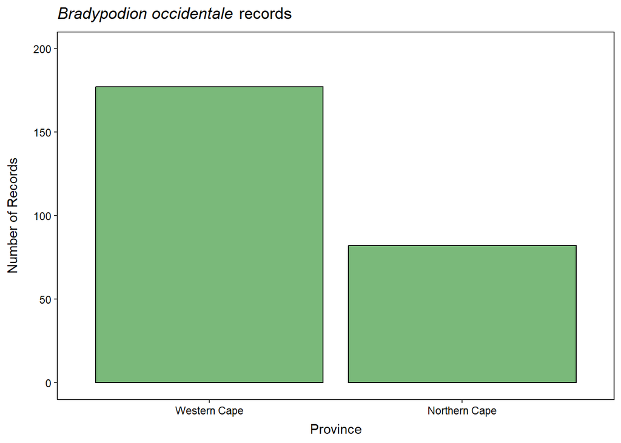

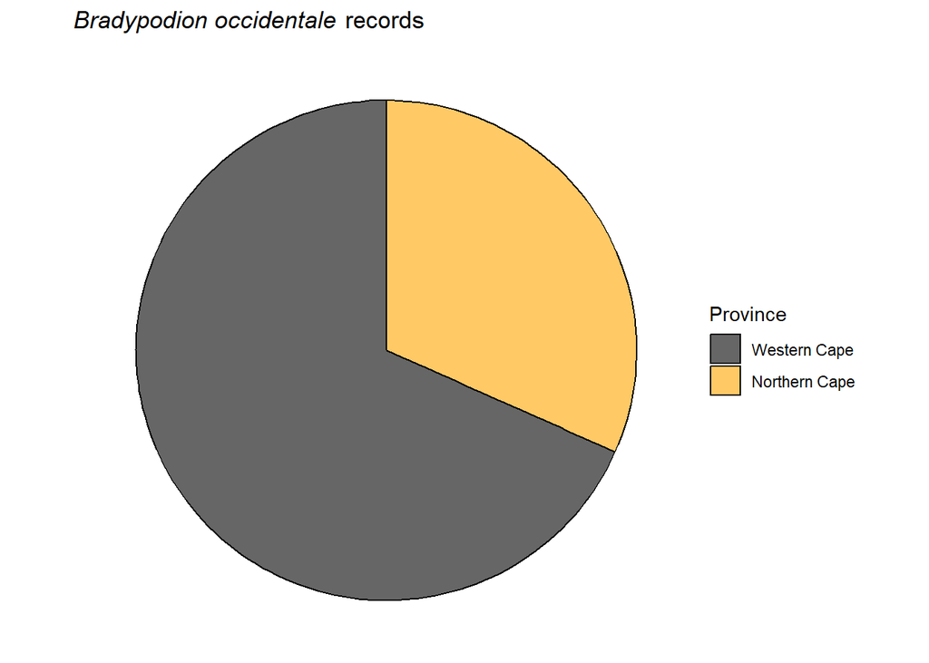

```
##            adm1   n percent
## 1  Western Cape 177    68.3
## 2 Northern Cape  82    31.7
```

### Exercise 3

Read in your *Bradypodion occidentale* GPS file again (RDS), and now plot it on a map of southern Africa. This map should contain South Africa, Namibia, Botswana, Zimbabwe, and Mozambique. Colour the points as in Exercise 2: Northern Cape = `orange` and the Western Cape = `black`. As before, include a scale bar and North arrow.

```r
southernafrica_ext = rnaturalearth::ne_countries(scale = "medium",
                  returnclass = "sf") %>%
                  dplyr::filter(name %in% c("South Africa", "Namibia", "Botswana", "Zimbabwe", "Mozambique"))
```

This is the result you need:

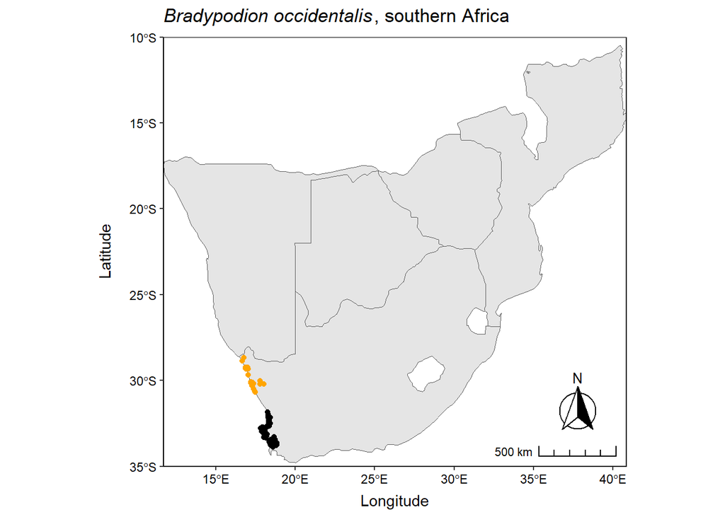

### Exercise 4

Using your *Bradypodion occidentale* GPS file, create a new column that contains only the year from the column called `eventDate`. I.e. `2025-01-13T07:30:14` should become `2025`. To do this, use the base R `substr()` function, where you provide the number of characters you want to retain. For example: `substr("Bradypodion", 1, 4)` will extract characters 1 to 4 from the word “Bradypodion”, returning “Brad”.

Your graph should resemble:

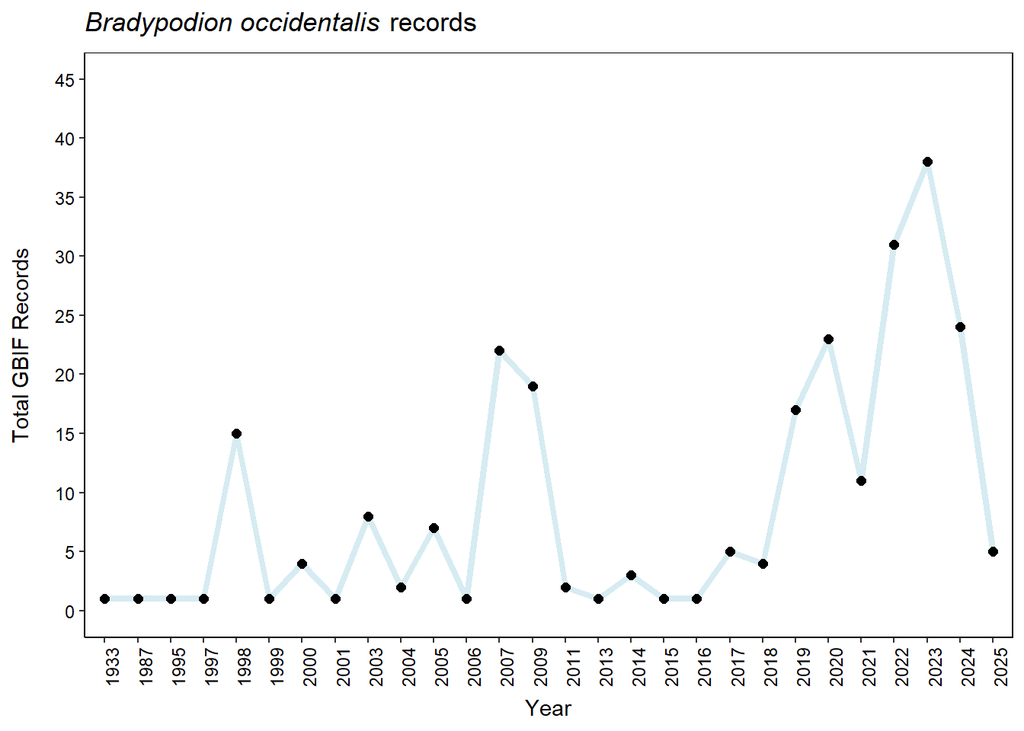

### Create a function

Create a dynamic function that automates the creation of the plot above. This function should read in a data frame that has been downloaded from GBIF, extract the year that each entry was recorded, tally up the counts for each year, and plot a line chart. Your function should include parameters for the following:

- line colour
- line thickness
- point size
- point shape
- angle of the x-axis labels
- the y min and y max values, and the y-interval

As a reminder, use the template below for building functions (the parameter names can be changed, these are just suggestions). It’s good practice to set default values where applicable, to avoid errors if the user doesn’t provide a value.

```r
plot.recs = function(data, line.col, line.w, pt.size, pt.shape, x.angle, ymin, ymax, breaks){

  data$shortdate = substr(data[[eventdate.col]], 1, 4)

  YOURPLOT = ggplot() +
  # your plotting code

  return(YOURPLOT)
}
```

Now, as a final touch to your function, add an error message if the user provides a column name that does not exist in the data frame they provide. Below is some pseudo-code to get you started. Remember that negations in R are denoted with an exclamation mark (`!`), and if you want to check whether one thing exists in another, you can use `%in%`.

```r
if (EVENTDATECOLUMN is not in the names(INPUTDATA)) {
    stop(paste0("Column ", EVENTDATECOLUMN, " not found in the data frame."))
  }
```

### Exercise 5

Download GBIF data for another two chameleon species: *Bradypodion ventrale* and *B. pumilum*.

- Save the data as RDS files
- Do the same as in Exercise 4, where you extract just the year from the `eventDate` column from these two additional species
- As before, create a data frame for each species with the total record counts for each year. Add a column called `species` to each with the correct species name.
- Create one merged data frame that contains all the record tallies for each year (use `rbind()`), for all three species
- Create two line plots (similar to Exercise 4); (1) with all three species on one plot, and (2) where each species is plotted in a separate panel. Use `facet_wrap(~species)` to achieve this
- Now create three separate plots, where each species is on its own scale. Experiment to set these optimally

You should end up with:

[figure not shown]

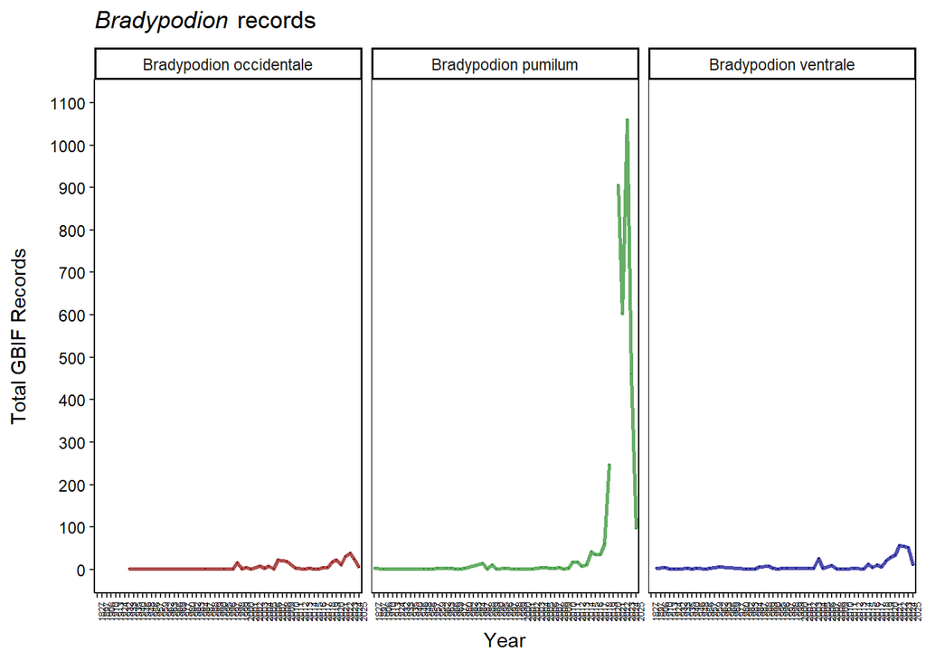

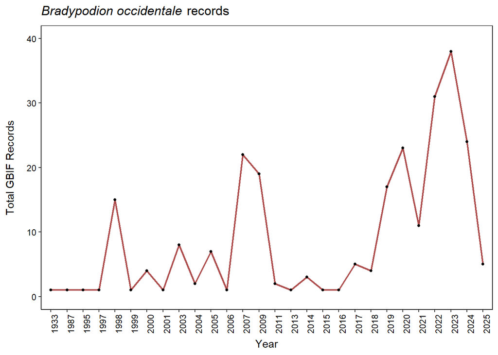

[figure not shown]

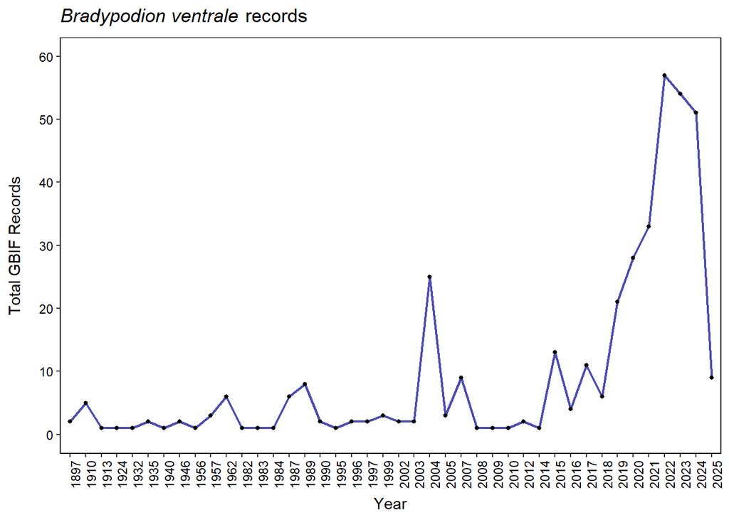

For the *Bradypodion ventrale* plot that you created above, create another version of this plot where you only show data for the years 2014 - 2025. Hint: use the `dplyr::filter()` function. If you already have a condition within the filter function, you can add more using the `&` symbol.

Lastly, add a horizontal line at y = 25. Make it a red, dashed line with a width of 0.5. Use `geom_hline()`.

You should end up with:

[figure not shown]

### Exercise 6

Read in the GBIF data you downloaded for your three chameleon species again. For this activity, we are interested in the `eventTime` column. These are the times at which the species was sighted, and could give some insight into each species’ active period (e.g. is it diurnal, nocturnal, crepuscular?). These times are not going to be completely accurate, but they give us something to work with from which we could draw some broad conclusions. In many cases, this might actually just represent when people are out and about, rather than the chameleons!

For you to do:

- Combine the data frames from your three chameloeon species into one data frame
- The `eventTime` lists times in the format `07:30:14+02:00`. The `+02:00` indicates Central African Time. In your data frame, remove the `+02:00` part of the string, and remove all NA values
- A good way to store times so that they are comparable is to convert the timestamps into minutes since midnight. Code is provided below to produce these values
- Using the data frame that contains the column with `mins_since_midnight`, create a ridgeline plot in ggplot, using the `geom_density_ridges()` function from the `ggridges` library
- See if you can adjust the x-axis labels to show times in the format `labels = c("00:00", "03:00", "06:00", "09:00", "12:00", "15:00", "18:00", "21:00", "24:00")` by using appropriate breaks in the `scale_x_continuous()` function. Some tips are given below

```r
# you need these three additional libraries
library(lubridate)
library(ggridges)
library(viridis)

# read in your chameleon data sets -> the first one is done for you
# here, we keep only the species and eventTime columns
b.occidentale = readRDS("data/sp_gps_b.occidentale_gbif.rds") %>%
  dplyr::select(species, eventTime)

# read in the other two here

# combine the three data frames into one data frame
brady.comb = dplyr::bind_rows(b.occidentale, DATA2, DATA3)

# remove +02:00 part of eventTime, and NAs
brady.comb = brady.comb %>%
  mutate(time_clean = gsub("\\+.*", "", eventTime)) %>%
  na.omit(eventTime)

head(brady.comb)

# add code here to keep only the species and time_clean columns going forward
brady.comb = brady.comb %>%
  dplyr::select(ADD CODE HERE)

# calculate the time since midnight for each time stamp
brady.comb.timesincemidnight = brady.comb %>%
  mutate(
    parsed_time = lubridate::parse_date_time(time_clean, orders = "HMS"),
    mins_since_midnight = lubridate::hour(parsed_time) * 60 + lubridate::minute(parsed_time)
  )

# take a look at the data frame
head(brady.comb.timesincemidnight)

ggplot(YOURDATA, aes(x = YOUR.X, y = YOUR.Y, fill = YOUR.FILL)) +
  geom_density_ridges(scale = 1.5, alpha = 0.75) +
  scale_x_continuous(
    # hint: you are working in minutes, and your time scale is from 0 to 24 hours in intervals of 3 hours
    breaks = seq(from = MINVAL, to = MAXVAL, by = BREAKVAL),
    labels = c(YOUR TIME LABELS)
  ) +
  labs(
    x = "Time of Day",
    y = "Species",
    title = "Bradypodion active periods"
  ) +
  # add this if you want default colours, otherwise set your own
  # you can use scale_fill_manual(values=c("red", "black", "orange"))
  scale_fill_viridis(discrete = TRUE, option = "D")
```

You should get something like this:

[output not shown]

```
##                   species time_clean         parsed_time mins_since_midnight
## 1 Bradypodion occidentale   07:30:14 0000-01-01 07:30:14                 450
## 2 Bradypodion occidentale   21:14:00 0000-01-01 21:14:00                1274
## 3 Bradypodion occidentale   21:13:21 0000-01-01 21:13:21                1273
## 4 Bradypodion occidentale   22:43:32 0000-01-01 22:43:32                1363
## 5 Bradypodion occidentale   22:43:42 0000-01-01 22:43:42                1363
## 6 Bradypodion occidentale   18:59:00 0000-01-01 18:59:00                1139
```

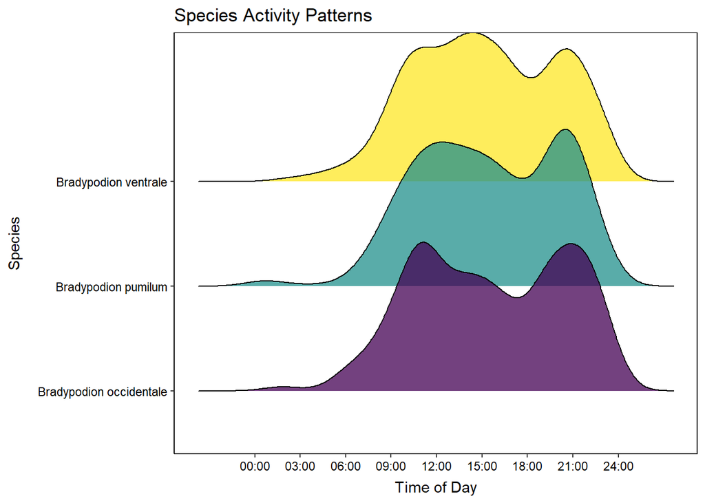

You can shift alter the overlap between plots by adjusting the `scale` parameter in `geom_density_ridges(scale = 1.5, alpha = 0.6)`. If you add `stat="binline"` into the function, your plot will change format into a barplot style:

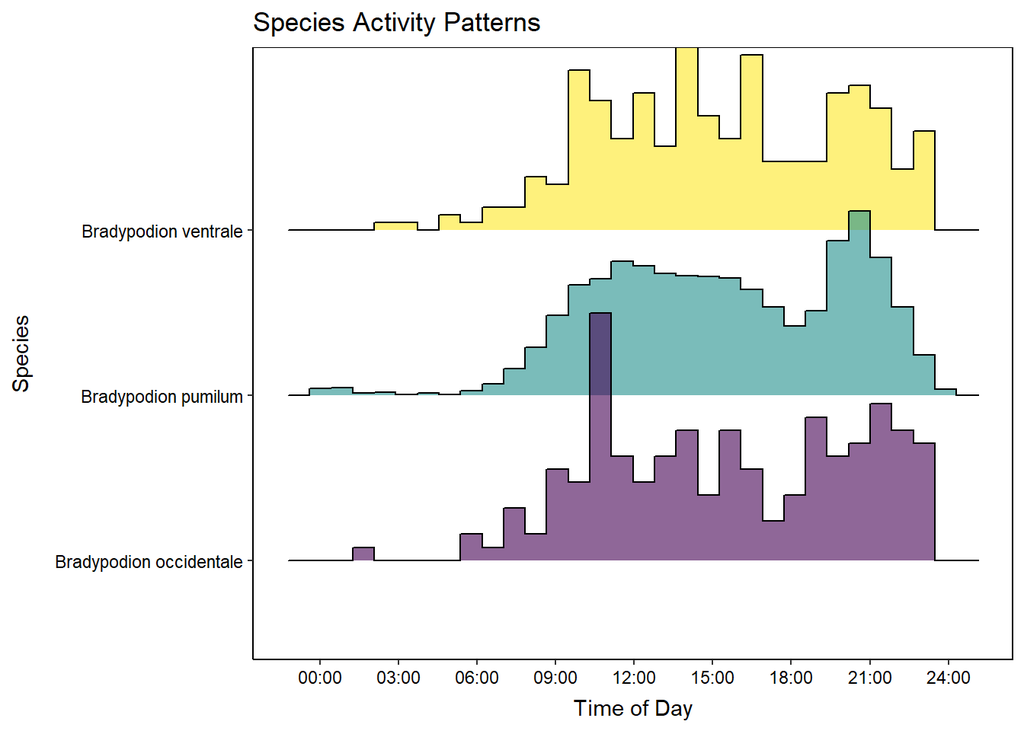

## SDM Exercises 🐦

### Exercise 1: What is a raster?

The Latin word *rastrum* means “rake”. It was also a special kind of five-pointed pen that was used to draw staff lines on music sheets before printers were around. Think of a raster as something that divides an area up into multiple grid lines.

[figure not shown]

This block of code creates a grid with 10 rows and 10 columns. The x and y-limits specify the geographic extent (i.e. just the space it occupies); x means longitude, y means latitude. It then creates random numbers for this 10x10 grid, such that each cell in the grid has its own value. Here, let’s pretend that this is temperature data. To create data that looks somewhat like temperature values, we can specify that the random numbers should have a normal distribution around a mean of 15, with a standard deviation of 3.

```r
# create a 10x10 grid, with a geographic extent of 0 to 10 degrees lon and 0 to 10 degrees lat
r10 = terra::rast(nrows = 10, ncols = 10, xmin = 0, xmax = 10, ymin = 0, ymax = 10)

set.seed(123)
# assign random values to each cell
terra::values(r10) = rnorm(terra::ncell(r10), mean = 15, sd = 3)
# give the data layer a name
names(r10) = "temperature"
# view the SpatRaster object
r10
```

```
## class       : SpatRaster
## dimensions  : 10, 10, 1  (nrow, ncol, nlyr)
## resolution  : 1, 1  (x, y)
## extent      : 0, 10, 0, 10  (xmin, xmax, ymin, ymax)
## coord. ref. : lon/lat WGS 84 (CRS84) (OGC:CRS84)
## source(s)   : memory
## name        : temperature
## min value   :    8.072493
## max value   :   21.561999
```

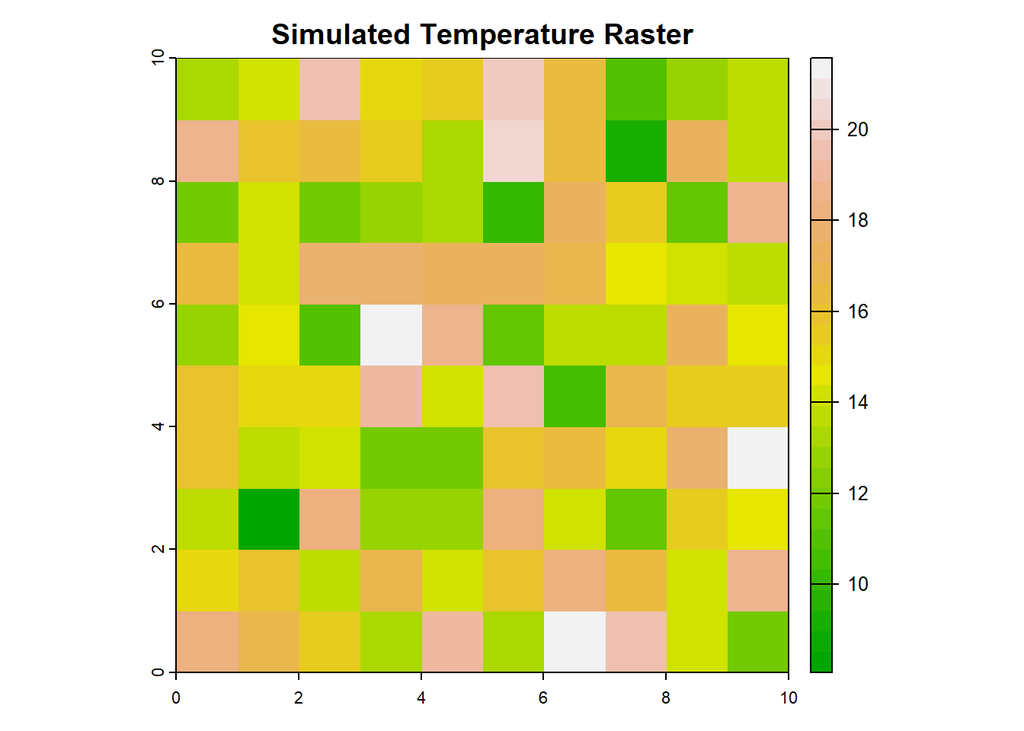

```r
# plot raster
terra::plot(r10, main = "Simulated Temperature Raster", col = terrain.colors(30))
```

```r
# display the number of cells in the grid
terra::ncell(r10)
```

```
## [1] 100
```

This is all a raster is, and each cell can have any type of value that represents some measure in space. Apart from climate variables, some examples are crime rates, pollution, human footprint data, fire and flood risk, snow cover, etc.

The resolution is calculated from the extent and dimensions (ncol and nrow) of the grid. Here, the x resolution = (xmax - xmin) / ncol = (10 - 0) / 10 = 1, and the y resolution = (ymax - ymin) / nrow = (10 - 0) / 10 = 1. In geographic space, this would equate to 1 x 1 degree grid cells on a map.

🟢 **For you to do:**

- Repeat the above code for making a raster with simulated data, but this time create a raster that is 25x25 grid cells in size (keep the x and y limits the same as before). Remember that the number of rows and columns in the same area of space affects the resolution. Compare this to the previous raster -> how do the resolutions differ?

Here are some tips:

```r
r25 = terra::rast(nrows = NROW, ncols = NCOL, xmin = 0, xmax = 10, ymin = 0, ymax = 10)

set.seed(123)
# assign random values to each cell
terra::values(r25) = rnorm(terra::ncell(r25), mean = 15, sd = 3)
names(r25) = "temperature"

# PLOT YOUR RASTER HERE
# FIND THE NUMBER OF CELLS IN THE RASTER (should be nrow x ncol)
```

You should see this 25x25 raster, which has 625 cells:

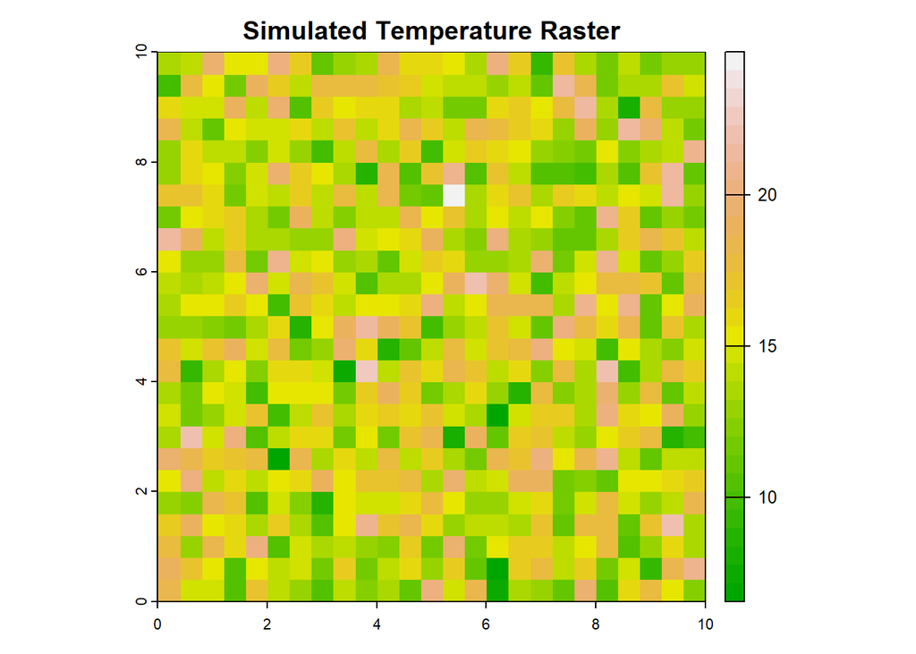

- Filter your raster so that only cells that have a value `> 15` are shown. When plotting, you can use `col = c("khaki", "black")` to colour cells that are `FALSE` `"khaki"`, and `TRUE` `"black"`. To filter a raster, all you need to do is: `FILTERED.RAST = ORIGINAL.RAST > VALUE`, where you can change the condition (e.g. `<`, `>=`, `<=`, or a few of these simultaneously)
- Filter your original raster again, this time keeping cells that are `> 18`. You can see your first filter of `> 15` as your “lenient” raster, and `> 18` as the more “stringent” one. Relate this idea to climatic suitability, and how one could filter suitable areas at different thresholds.

The filtered rasters should look like this (which are actually now binary rasters, since each cell is one of two states: larger or smaller than the threshold value):

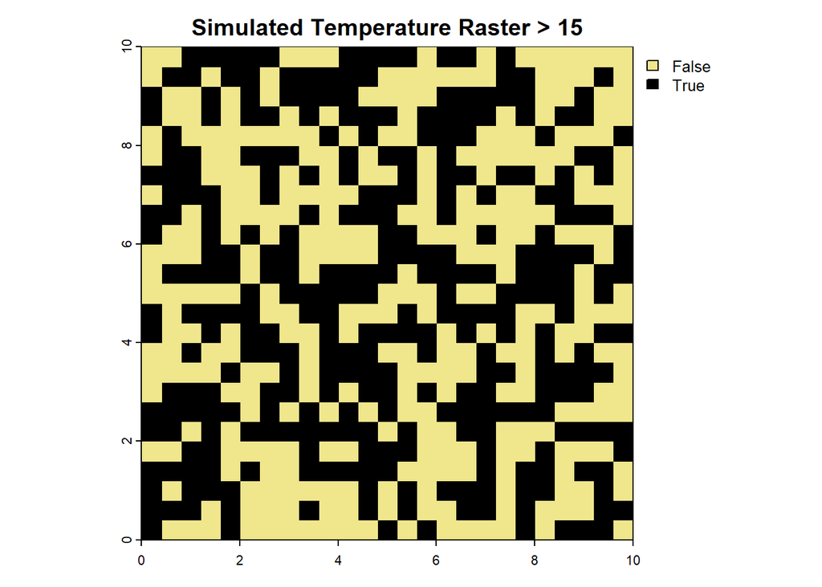

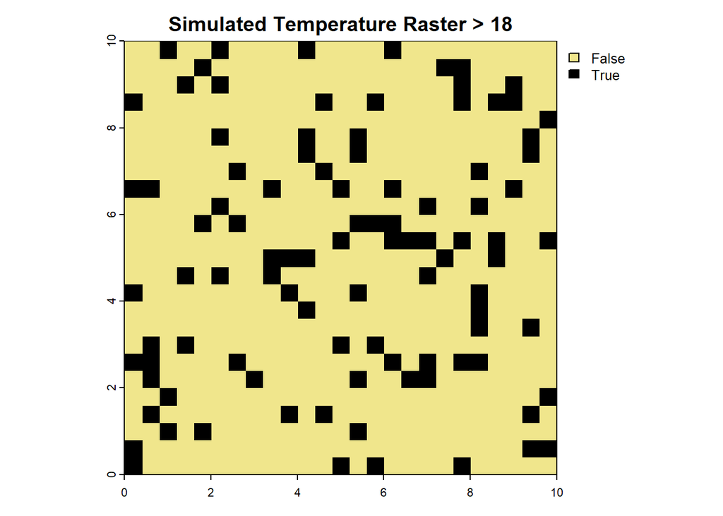

- Calculate the percentage of `TRUE` cells in each of the two scenarios. You can use `terra::freq(RASTER)` to count the number of cells in each category within the layer. After applying a filter to a raster, you will end up with a binary map. Each cell will contain a `TRUE (1)` or `FALSE (0)` entry depending on whether it met your condition or not

You should find this for the > 15 raster:

```
##   layer value count
## 1     1     0   314
## 2     1     1   311
```

And this for the > 18 raster:

```
##   layer value count
## 1     1     0   527
## 2     1     1    98
```

Calculate the percentage change between the two. The difference here means that when we changed our filter from keeping values `> 15` to values `> 18` (increased stringency), the area remaining on the grid decreased by X%. This concept is pretty much what is referred to when you read about **relative occurrence area (ROA)** in the SDM literature.

### Exercise 2: Raster layers

Exercise 1 simulated temperature data, and added that as a layer to a raster object (of class `SpatRaster`). Rasters usually have multiple layers, where each layer is a different variable. These layers are contained within the raster object in the same way different objects are contained inside a list, and can be accessed in the same way (e.g. using `$`). All layers need to be in the same resolution.

In this exercise, we will create two new simulated data sets:

- Pollution values on a scale of **0 to 100**, where we’ll simulate a pollution hub (perhaps a factory) at the center of a 100x100 raster grid
- Normalized Difference Vegetation Index **(NDVI)**: this is a greenness index that is a measure of vegetation cover, calculated using near-infrared and red electromagnetic radiation bands. Values range between **-1 and 1**, where negative values indicate snow, clouds or water, small positive values indicate barren land cover, and values > 0.5 indicate dense forest or vegetation. We’ll simulate NDVI values here, on another 100x100 raster grid, where the value in each cell is determined by the pollution value in our first raster (the higher the pollution value, the lower the NDVI value, and vice-versa)

These simulations are already done for you; just copy over the code blocks below and run them. Comments are provided to explain what each step does, if you are interested in the details.

Note that the simulations calculate the distance of each raster cell to the pollution source as a Euclidean distance:

$$d = \sqrt{(x_2 - x_1)^2 + (y_2 - y_1)^2}$$

This is fine for 2D rasters, but will be inaccurate if you are working with lat and lon data, as this doesn’t account for Earth’s curvature! Also, in reality, pollution levels around a central source will be affected by other factors too, not just raw distance (e.g. wind, topography of the land).

**Simulate the pollution raster:** 🏭

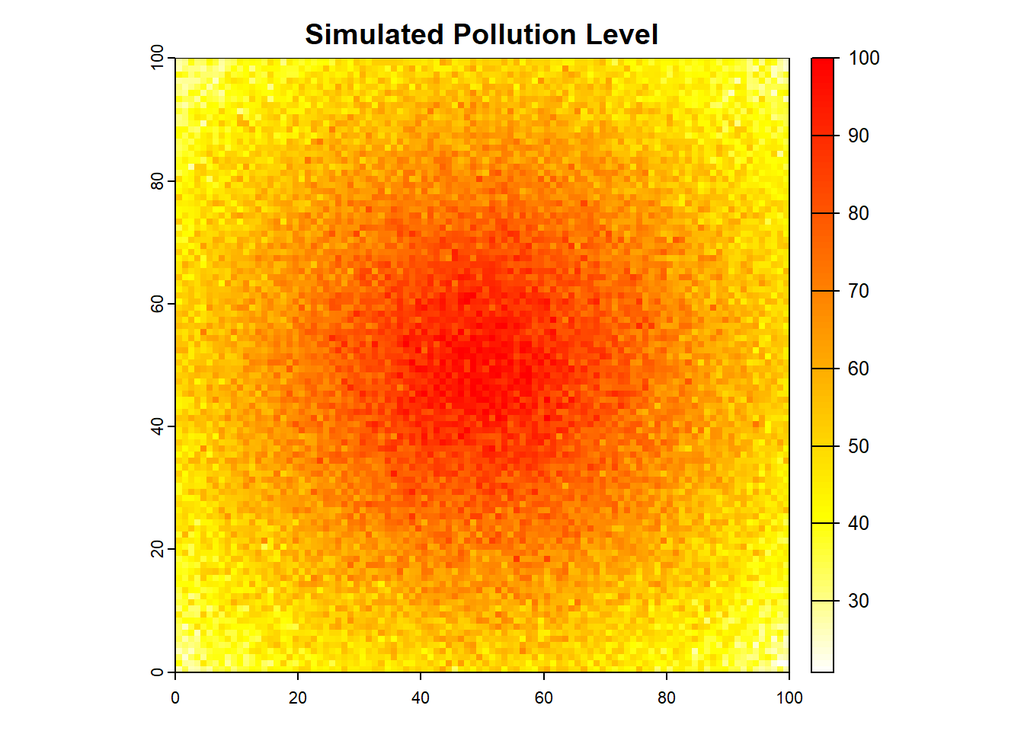

```r
# Create a blank raster: 100x100 = 10,000 cells in the grid
# set the extent to be from 0 to 100 degrees East, and 0 to 100 degrees North
pollution_raster = rast(nrows = 100, ncols = 100,
                         xmin = 0, xmax = 100,
                         ymin = 0, ymax = 100)

set.seed(123)
# extract the coordinates for the center of each grid cell in the raster: here we'll end up with 10,000 points with an x and y value
coords = terra::xyFromCell(pollution_raster, 1:ncell(pollution_raster))
# let's set the center of the raster as where our simulated factory (or source of pollution) might be
center = c(50, 50)  # industrial center -> in a 100x100 grid, the center is at x = 50 and y = 50

# get the Euclidean distance from each raster cell to the center (i.e. distance from the pollution source)
dist_to_center = sqrt((coords[,1] - center[1])^2 + (coords[,2] - center[2])^2)

# calculate a pollution value on a scale of 0 to 100
# here, a cell dead in the center would have the highest possible pollution value:
# 100 - 0 = 100
# a point that is 60 units away will have a pollution value of 40 etc.
# the rnorm() part just adds some variation to the values, to simulate a somewhat more natural situation. The higher sd is, the more variation in the simulated data
pollution_values = 100 - dist_to_center + rnorm(length(dist_to_center), mean = 0, sd = 5)

# Force any negative values to become 0 -> otherwise it isn't meaningful!
pollution_values = pmax(pollution_values, 0)

# Force any values over 100 to become 100
pollution_values = pmax(pmin(pollution_values, 100), 0)

# Assign values to raster
terra::values(pollution_raster) = pollution_values
names(pollution_raster) = "pollution"

# Plot the raster
plot(pollution_raster, main = "Simulated Pollution Level",
     col = rev(heat.colors(100))) # rev reverses the colour scale
```

**Simulate the NDVI (vegetation cover) raster:** 🌿

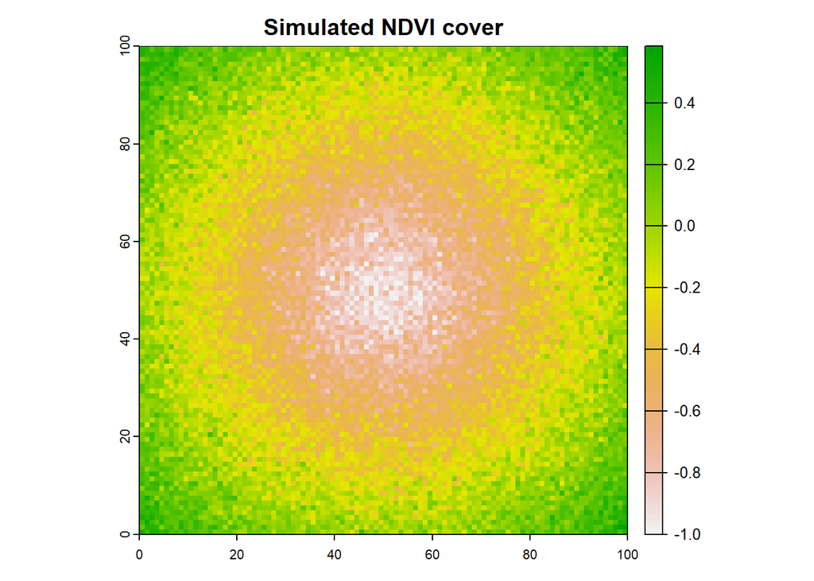

```r
ndvi_raster = rast(nrows = 100, ncols = 100,
                    xmin = 0, xmax = 100,
                    ymin = 0, ymax = 100)

# Use pollution values to determine NDVI: higher pollution = lower NDVI
# calculate a NDVI values on a scale of -1 to 1
ndvi_values = 1 - (pollution_values / 50) # divide by 50 here, but decrease to make ndvi more sensitive to pollution, or increase to make it less sensitive

# Constrain NDVI to the range -1 to 1
ndvi_values = pmin(pmax(ndvi_values, -1), 1)

# Assign NDVI values to the raster
terra::values(ndvi_raster) = ndvi_values
names(ndvi_raster) = "ndvi"

plot(ndvi_raster, main = "Simulated NDVI cover",
     col = rev(terrain.colors(100)))
```

🟢 **Your tasks are to:**

- Combine the `pollution_raster` and `ndvi_raster` rasters into a single raster. You can simply use `c()` to do this. Each raster is now a layer within a new raster. For example:

```r
RASTER1
RASTER2

COMBINED = c(RASTER1, RASTER2)
```

- Plot the ndvi layer, where you apply a threshold of `ndvi > 0.25`
- Calculate the percentage of cells in the ndvi raster with a value > 0.25
- Extract the values from each layer (NDVI and pollution) using `terra::values(RASTERLAYER)`, and combine them into one data frame. When you extract from a raster, the result is usually a matrix. You can convert a matrix to a data frame (DF) using `as.data.frame()`. To combine the DFs, use `cbind()`. For example:

```r
# Extract values from each cell in VALUES.A raster
VALUES.A = terra::values(RASTER$LAYER.A) %>%
  as.data.frame() # convert to a DF

# Extract values from each cell in VALUES.B raster
VALUES.B = terra::values(RASTER$LAYER.B) %>%
  as.data.frame()

# use cbind() to merge the two DFs
COMBINED.VALUES = cbind(VALUES.A, VALUES.B)
```

- Create a ggplot (`geom_jitter()`) showing pollution vs ndvi. The jitter plot differs from point plots in that it tries to avoid overlapping points

Your binary raster should look something like this:

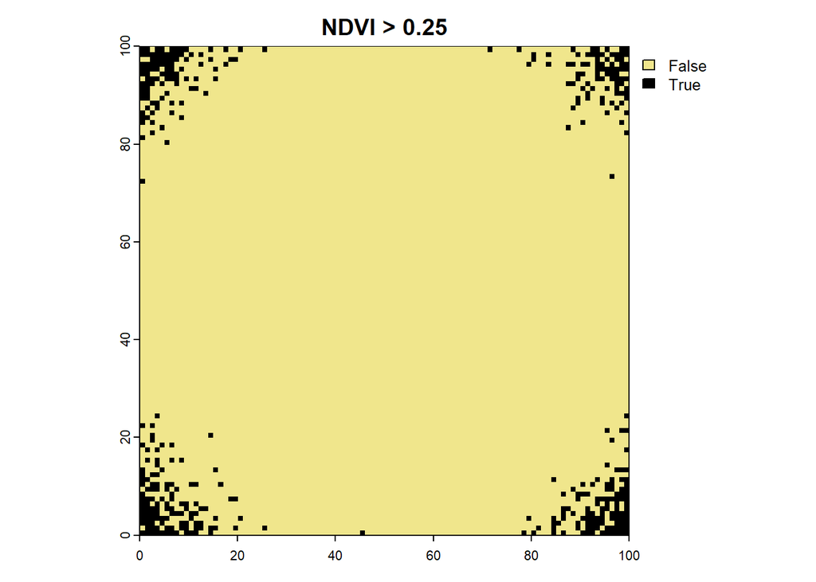

```
##   layer value count
## 1     1     0  9594
## 2     1     1   406
```

And your pollution vs ndvi plot should resemble:

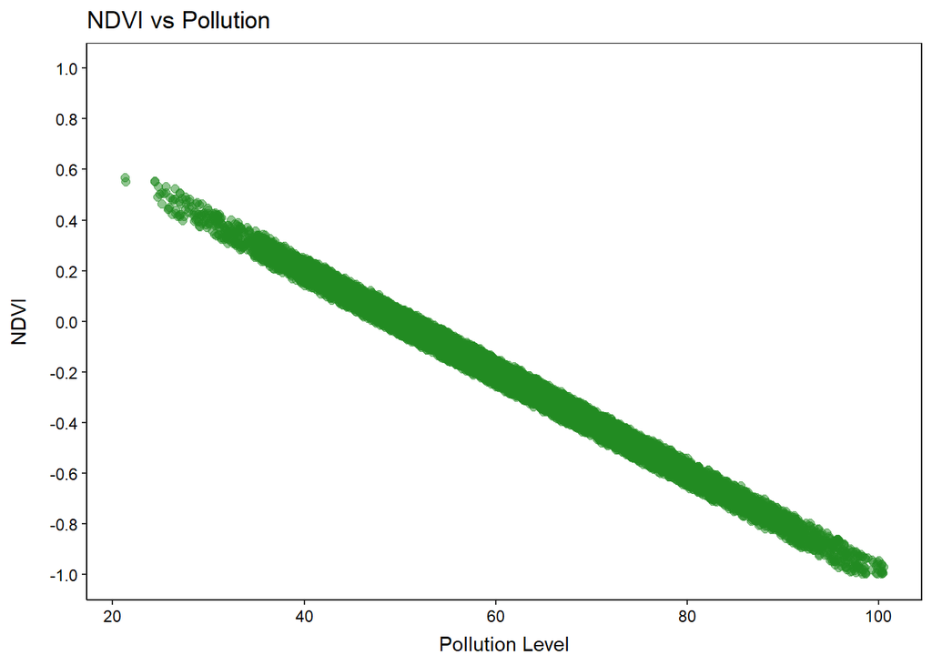